# HW 03 - Road traffic accidents

Max Asmar

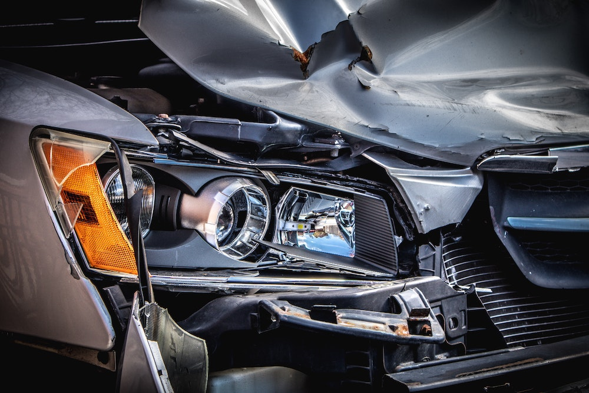

Photo by Clark Van Der Beken on Unsplash

In this assignment we’ll look at traffic accidents in Edinburgh. The data are made available [online](https://data.gov.uk/dataset/cb7ae6f0-4be6-4935-9277-47e5ce24a11f/road-safety-data/datafile/36f1658e-b709-47e7-9f56-cca7aefeb8fe/preview) by the UK Government. It covers all recorded accidents in Edinburgh in 2018 and some of the variables were modified for the purposes of this assignment.

# Getting started

## Learning Objectives

In this assignment, you will practice:

- Creating density plots to show distributions over time
- Using `mutate()` and `if_else()` to create new categorical variables
- Faceting plots to compare groups
- Interpreting visualizations in context of data
- Designing your own multi-variable visualization

Navigate to your `homework-instructions` repo in JupyterHub, open the `HW03` folder, and open the R Markdown document `hw-03.Rmd`. Knit it to make sure it compiles without errors.

## Warm up

Before we introduce the data, let’s warm up with some simple exercises.

**Complete these steps:**

1. Update the YAML, changing the author name to your name
2. **Knit** the document
3. **Commit** your changes with message: `"Updated author name"`
4. **Push** to GitHub
5. Verify your changes are visible in your GitHub repo (check both .Rmd and .md files)

If anything is missing, commit and push again.

## Packages

We’ll use the **tidyverse** package for much of the data wrangling and visualization and the data lives in the **dsbox** package. These packages are already installed for you. You can load them by running the following in your Console:

```r
library(tidyverse)
library(dsbox)
```

## Data

The data can be found in the **dsbox** package, and it’s called `accidents`. Since the dataset is distributed with the package, we don’t need to load it separately; it becomes available to us when we load the package. You can find out more about the dataset by inspecting its documentation, which you can access by running `?accidents` in the Console or using the Help menu in RStudio to search for `accidents`. You can also find this information [here](https://rstudio-education.github.io/dsbox/reference/accidents.html).